# Ejercicio 7

Cristóbal Marchant

2022-07-10

## 1. Ejemplo de regresión lineal simple utilizando un conjunto de datos con dos variables y la función lm.

Se crea un conjunto de datos para 2 variables a partir de las estadisticas de los Pokemon iniciales de cada region.

```r
# Vida Base Pokemon inicial
VB=c(78,79,80,78,85,80,80,100,70,76,84,95,110,95,75,75,72,88,95,80,78,80,70,100)
# Daño de ataque base Pokemon inicial
DA= c(84,83,82,84,105,82,120,110,85,104,86,109,123,100,75,69,95,107,115,74,107,115,85,125)
```

Grafique utilizando las funciones plot y abline. La función lm se utiliza para ajustar modelos lineales:

```r
lm.fit=lm(VB~DA)
lm.fit
```

```
##
## Call:
## lm(formula = VB ~ DA)
##
## Coefficients:
## (Intercept)           DA
##      42.887        0.419
```

```r
summary(lm.fit)
```

```
##
## Call:
## lm(formula = VB ~ DA)
##
## Residuals:
##     Min      1Q  Median      3Q     Max
## -13.165  -8.500   1.013   4.825  15.578
##
## Coefficients:
##             Estimate Std. Error t value Pr(>|t|)
## (Intercept) 42.88728    9.74743   4.400 0.000227 ***
## DA           0.41898    0.09925   4.222 0.000351 ***
## ---
## Signif. codes:  0 '***' 0.001 '**' 0.01 '*' 0.05 '.' 0.1 ' ' 1
##
## Residual standard error: 7.98 on 22 degrees of freedom
## Multiple R-squared:  0.4475, Adjusted R-squared:  0.4224
## F-statistic: 17.82 on 1 and 22 DF,  p-value: 0.0003512
```

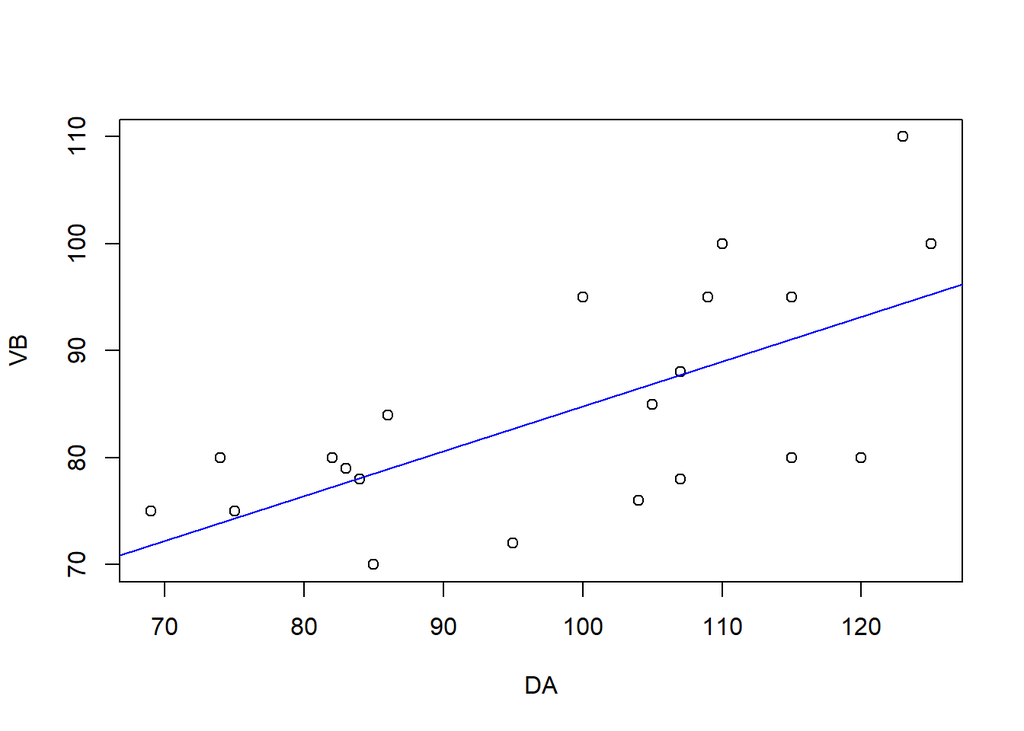

```r
plot(VB~DA)
abline(42.887 , 0.419,col='blue')
```

## 2. Modelo de regresión lineal simple de la actividad 1 para predecir 5 nuevos registros e incorpórelos a su conjunto de datos.

```r
DA_P<-c(3,46,78,105,147)

predict.lm(lm.fit,data.frame(DA=DA_P))
```

```
##         1         2         3         4         5
##  44.14422  62.16028  75.56758  86.87999 104.47707
```

Se Calcula nuevamente la regresión lineal simple

```r
VB = append(VB, c(44.14422, 62.16028, 75.56758, 86.87999, 104.47707))
DA = append(DA, DA_P)
lm.fit=lm(VB~DA)
lm.fit
```

```
##
## Call:
## lm(formula = VB ~ DA)
##
## Coefficients:
## (Intercept)           DA
##      42.887        0.419
```

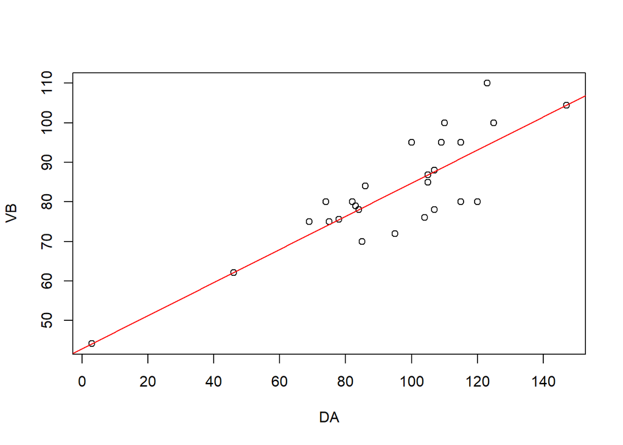

```r
plot(VB~DA)
abline(42.887 , 0.419,col='red')
```

¿Se observa algún cambio en los coeficientes?

R= No se muestra ningun cambio, ya que la función de predicciones sigue el modelo del objeto, es decir, sobre la regresión lineal que poseemos

## 3. Tome un punto cualquiera de su conjunto de datos y multiplíquelo por 100

```r
VB_Aux = append(VB, 85*100)
DA_Aux = append(DA, 105*100)
lm.fit = lm(VB_Aux~DA_Aux)
lm.fit
```

```
##
## Call:
## lm(formula = VB_Aux ~ DA_Aux)
##
## Coefficients:
## (Intercept)       DA_Aux
##      6.5773       0.8088
```

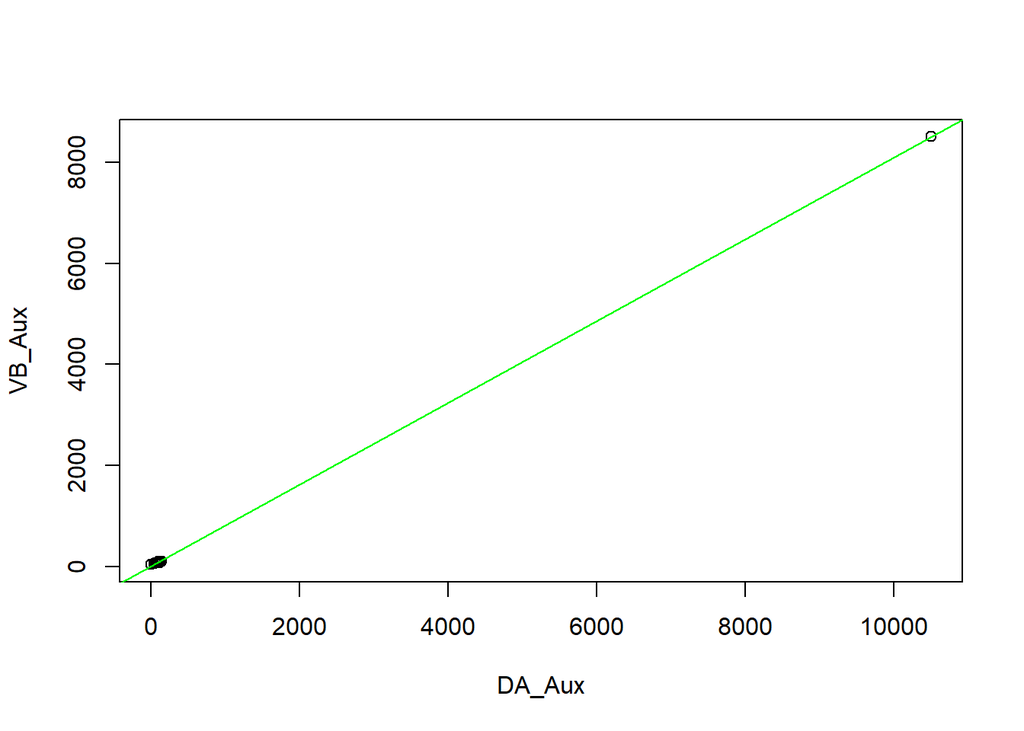

```r
plot(VB_Aux~DA_Aux)
abline( 6.5773 , 0.8088,col='green')
```

¿Se observa algún cambio en los coeficientes?

Se nota un cambio en la disminución y un aumento en los coeficientes resultantes respectivamente, cambiando asi, el modelo lineal, esto debido a que al multiplicar por 100 ambos nuevos valores da un resultado distinto al del metodo de predicción (metodo que sigue el modelo lineal)